# INPC_1969_2022

Tao Jesus Veloz

2022-06-09

## Índice Nacional de Precios al Consumidor

La elaboración y publicación del INPC se inició en 1969 por parte del Banco de México. A partir de esa fecha el INPC se ha actualizado en seis ocasiones, por lo que el Cambio de Año Base de 2010 a 2018, fue la séptima actualización

El INPC se ha consolidado como uno de los principales indicadores del desempeño económico del país; Además de su utilización como medida de la inflación, cabe destacar su uso como:

*Factor de actualización de los créditos fiscales.

*Determinante del valor de la Unidad De Inversión (UDI).

*Factor para actualizar la Unidad de Medida y Actualización (UMA)

Mediante los índices, se puede obtener la viariación porcentual de cualquier periodo utilizando la siguiente fórmula: Variación = (Valor del índice en el periodo actual / Valor del indice en el periodo anterior - 1) * 100

Ejemplo 1: Para obtener la variación anual del INPC de cualquier periodo, en este caso de diciembre de 2016 contra el mismo periodo del año anterior, se obtiene de la siguiente forma:

Valor del INPC en diciembre de 2016: 122.515 Valor del INPC en diciembre de 2015: 118.532

Variación = ( 122.515 / 118.532 - 1 ) * 100 = 3.36

### Ajustes inflacionarios

Los datos afectados por el valor del dinero en el tiempo se deben ajustar antes de modelarse. Esto se debe a la inflación: sus abuelos podían comprar una coca y un gansito tal vez con menos de 3 pesos. ¿Cuánto dinero necesitarían hoy para comprar una coca y un gansito? Entonces, las series de tiempo financieras se ajustan a la inflación, y se expresan en términos de alguna moneda constante (en el tiempo). Por ejemplo, se puede medir el valor de la vivienda en Gudalajara, con precios constantes de 2010 (imaginando que no hubiera cambiado el valor del dinero en el tiempo).

Para realizar el ajuste inflacionario, se toma un índice de precios. Si $z_t$ es el índice de precios y $y_t$ es el valor original de la vivienda en el tiempo $t$, entonces el precio de la vivienda, $x_t$, ajustado a valor del año 2010, estaría dado por:

$$x_t = \frac{y_t}{z_t} * z_{2010}$$

```
##      Min.   1st Qu.    Median      Mean   3rd Qu.      Max.
##   0.01159   0.08485  15.09810  34.49802  65.12443 109.27100
```

```
## [1] 35.94381
```

```
## [1] 1291.957
```

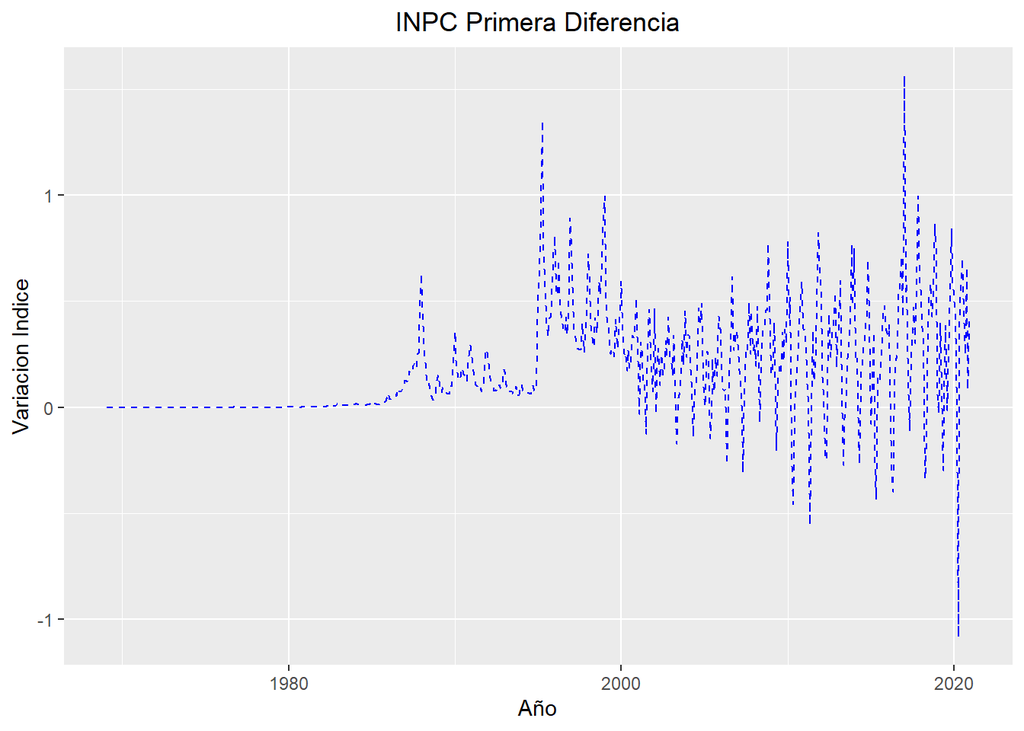

```
## Augmented Dickey-Fuller Test
## alternative: stationary
##
## Type 1: no drift no trend
##      lag    ADF p.value
## [1,]   0  0.412   0.762
## [2,]   1 -0.309   0.555
## [3,]   2 -0.362   0.540
## [4,]   3 -0.457   0.512
## [5,]   4 -0.537   0.487
## [6,]   5 -0.559   0.479
## [7,]   6 -0.571   0.474
## Type 2: with drift no trend
##      lag   ADF p.value
## [1,]   0 -7.40   0.010
## [2,]   1 -2.22   0.240
## [3,]   2 -2.19   0.251
## [4,]   3 -2.02   0.321
## [5,]   4 -2.00   0.329
## [6,]   5 -1.95   0.348
## [7,]   6 -1.95   0.347
## Type 3: with drift and trend
##      lag    ADF p.value
## [1,]   0  3.759   0.990
## [2,]   1  0.236   0.990
## [3,]   2  0.148   0.990
## [4,]   3 -0.159   0.990
## [5,]   4 -0.314   0.990
## [6,]   5 -0.400   0.986
## [7,]   6 -0.418   0.986
## ----
## Note: in fact, p.value = 0.01 means p.value <= 0.01
```

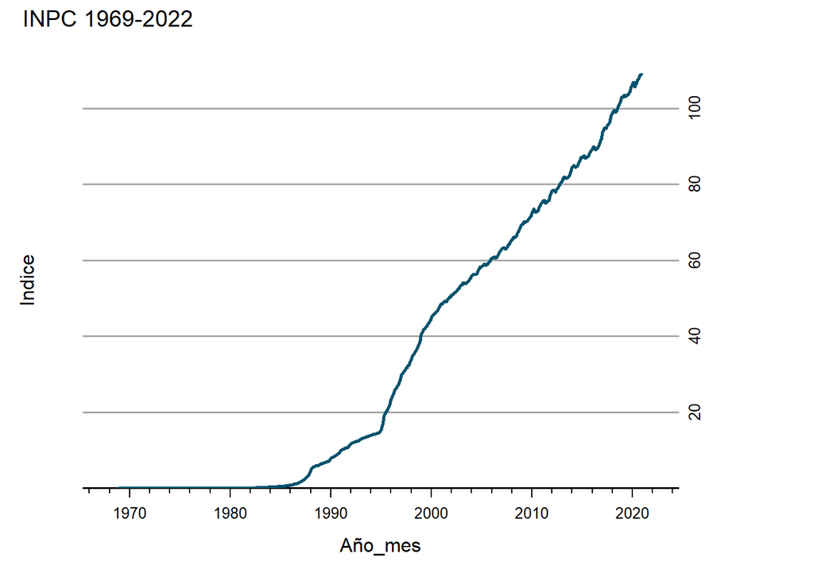

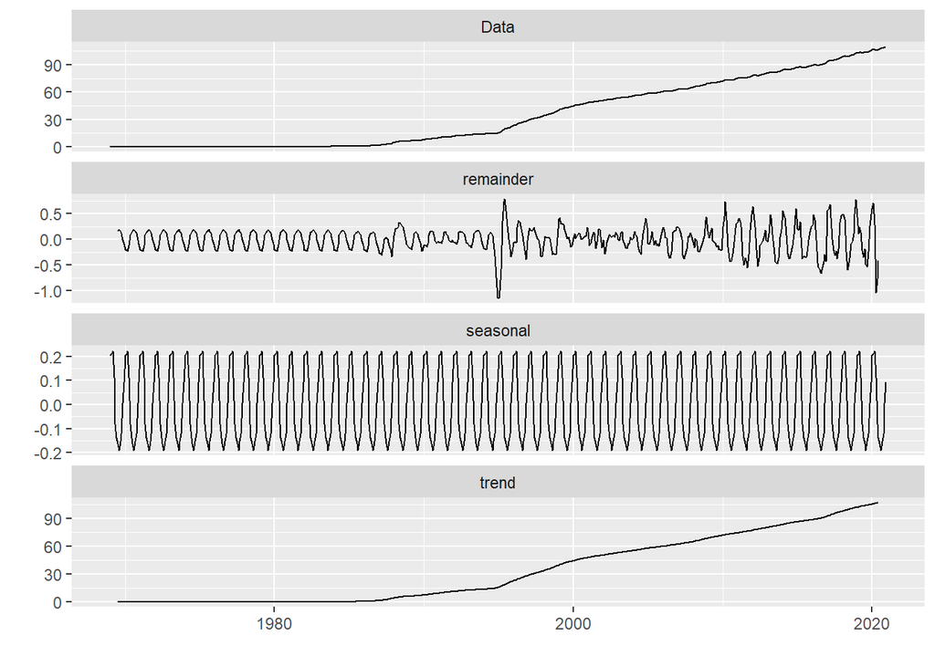

Las series de tiempo pueden presentar varios patrones, y comúnmente es útil dividir o descomponer la serie en cada uno de esos patrones. Recordando, una serie de tiempo puede exhibir:

- Tendencia
- Estacionalidad
- Ciclos

Al realizar la descomposición de la serie, usualmente se juntan el patrón cíclico y la tendencia en uno solo, llamado simplemente **tendencia**. Así, tendríamos tres componentes en una serie de tiempo cualquiera:

1. Tendencia
2. Estacionalidad
3. Residuo (lo que no es parte ni de la tendencia, ni del efecto estacional)

### Diferenciación

*Una manera de convertir una serie en estacionaria es calculando las diferencias entre observaciones consecutivas*. A esto se le llama **diferenciar** la serie.

$$y_{t}^{\prime}=y_{t}-y_{t-1}$$

Los datos en primeras diferencias tendrán $T - 1$ observaciones, porque no es posible calcular la diferencia para la primera observación.

- Las transformaciones logarítmicas pueden ayudar a **estabilizar la varianza** de una serie.
- La diferenciación puede ayudar a **estabilizar la media** de una serie de tiempo, al quitar los cambios de nivel en ella y reducir o eliminar tendencia o estacionalidad.

Otra forma de determinar gráficamente si una serie de tiempo es estacionaria o no, es viendo su función de autocorrelación, ACF. Para una serie de tiempo estacionaria, la ACF se vuelve cero rápidamente, mientras que una serie no estacionaria decae lentamente y el valor del primer rezago es muy alto y positivo.

### Diferenciación de segundo orden

A veces, la serie diferenciada parecerá seguir siendo no estacionaria, por lo que se puede recurrir a las **segundas diferencias**. Esto es, diferenciar las primeras diferencias:

$$\begin{aligned}
y_{t}^{\prime \prime} &=y_{t}^{\prime}-y_{t-1}^{\prime} \\
&=\left(y_{t}-y_{t-1}\right)-\left(y_{t-1}-y_{t-2}\right) \\
&=y_{t}-2 y_{t-1}+y_{t-2}
\end{aligned}$$

La serie en segundas diferencias tendrá $T-2$ observaciones. La interpretacion de $y_{t}^{\prime \prime}$ es que representa *los cambios en los cambios* de la serie.

### Pruebas de raíz unitaria

Para poder determinar más formalmente si una serie es estacionaria o no, se pueden llevar a cabo pruebas de **raíz unitaria**.

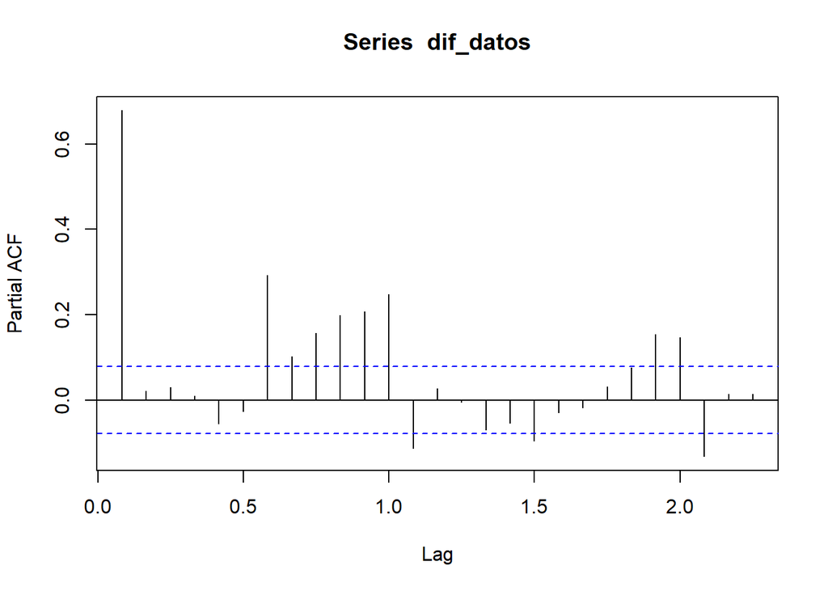

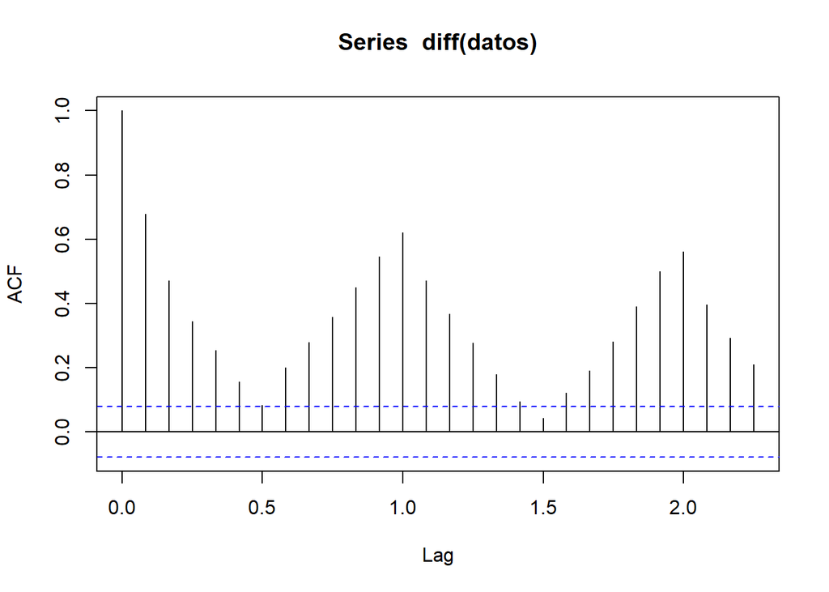

```
## Augmented Dickey-Fuller Test
## alternative: stationary
##
## Type 1: no drift no trend
##      lag   ADF p.value
## [1,]   0 -8.53    0.01
## [2,]   1 -7.44    0.01
## [3,]   2 -6.48    0.01
## [4,]   3 -5.90    0.01
## [5,]   4 -5.75    0.01
## [6,]   5 -5.41    0.01
## [7,]   6 -3.61    0.01
## Type 2: with drift no trend
##      lag    ADF p.value
## [1,]   0 -10.87    0.01
## [2,]   1  -9.77    0.01
## [3,]   2  -8.76    0.01
## [4,]   3  -8.19    0.01
## [5,]   4  -8.19    0.01
## [6,]   5  -7.94    0.01
## [7,]   6  -5.50    0.01
## Type 3: with drift and trend
##      lag    ADF p.value
## [1,]   0 -12.53    0.01
## [2,]   1 -11.56    0.01
## [3,]   2 -10.62    0.01
## [4,]   3 -10.19    0.01
## [5,]   4 -10.51    0.01
## [6,]   5 -10.53    0.01
## [7,]   6  -7.48    0.01
## ----
## Note: in fact, p.value = 0.01 means p.value <= 0.01
```

# Estacionariedad y diferenciación

Una serie de tiempo **estacionaria** es aquella en la cual sus propiedades no dependen del tiempo en que son medidas. Por lo tanto, una serie con tendencia y/o estacionalidad no es estacionaria.

Sin embargo, una serie con un comportamiento cíclico sí es estacionaria, ya que la ciclicidad no es de un periodo de tiempo fijo.

En general, una serie de tiempo estacionaria no tendrá patrones predecibles en el largo plazo. Gráficas de tiempo de series estacionarias mostrarán series horizontales (con o sin ciclos), y con una **varianza constante**.

### Características de la función de autocorrelación, ACF

La función `feat_acf()` provee características interesantes acerca de una serie de tiempo:

- El primer coeficiente de autocorrelación de los datos originales, `acf1`.
- La suma del cuadrado de los primeros 10 coeficientes de autocorrelación, de los datos originales, `acf10`. Este coeficiente nos dice qué tanta autocorrelación tiene la serie, sin importar el rezago.
- El primer coeficiente de autocorrelación de las primeras diferencias, `diff1_acf1`.
- La suma del cuadrado de los primeros 10 coeficientes de autocorrelación, de las primeras diferencias, `diff1_acf10`.
- El primer coeficiente de autocorrelación de las segundas diferencias, `diff2_acf1`.
- La suma del cuadrado de los primeros 10 coeficientes de autocorrelación, de las segundas diferencias, `diff2_acf10`.
- Para datos estacionales, también se obtiene el coeficiente de autocorrelación en el primer rezago estacional.

# Modelos AR y MA

## Modelos autorregresivos (AR)

Un modelo autorregresivo de orden *p* se define como

$$y_{t}=\phi_0+\phi_{1} y_{t-1}+\phi_{2}
y_{t-2}+\cdots+\phi_{p} y_{t-p}+\varepsilon_{t}$$
donde $\varepsilon_{t}$ es ruido blanco. Si observamos bien la ecuación, se asemeja mucho a una ecuación de regresión lineal múltiple, con la diferencia de que, ahora, los parámetros no son $\beta$, sino $\phi$ y que las regresoras (variables $x$), ahora son valores rezagados de la variable dependiente, $y_t$. Este sería un **modelo AR(*p*)**: modelo autorregresivo de orden *p*.

Para un modelo **AR(1):** $y_{t}=\phi_0+\phi_{1} y_{t-1}+ \varepsilon_{t}$, tenemos algunas situaciones, dependiendo los valores de $\phi_0$ y $\phi_1$:

- Si $\phi_1 = 0$, la serie es equivalente a un **ruido blanco** ($y_{t}=\phi_0+ \varepsilon_{t}$).
- Si $\phi_1 = 1$ y $\phi_0 = 0$, la serie es equivalente a una **caminata aleatoria**.
- Si $\phi_1 = 1$ y $\phi_0 \neq 0$, la serie es equivalente a una **caminata aleatoria con deriva**.
- Si $\phi_1 \lt 0$, $y_t$ tiende a oscilar alrededor de su media.

## Modelos de media móvil (MA)

Los modelos autorregresivos utilizan las observaciones pasadas para modelar. Los modelos de media móvil utilizan los **errores o residuos pasados** para modelar el pronóstico.

$$y_{t}=\theta_0
+\varepsilon_{t}+\theta_{1} \varepsilon_{t-1}+\theta_{2}
\varepsilon_{t-2}+\cdots+\theta_{q} \varepsilon_{t-q}$$
$\varepsilon_{t}$ es ruido blanco y a esto se le conoce como un modelo **MA(*q*)** de orden *q*.

Los modelos de media móvil buscan pronosticar valores futuros.

# Modelos ARIMA no estacionales

Si juntamos lo visto hasta ahora (diferenciación, modelos autorregresivos y de media móvil), obtenemos un modelo ARIMA no estacional.

ARIMA es el acrónimo de “AutoRegressive Integrated Moving Average”, o modelo AutoRegresivo integrado de Media Móvil. El modelo puede ser escrito así:

$$y_{t}^{\prime}=c+\phi_{1}
y_{t-1}^{\prime}+\cdots+\phi_{p} y_{t-p}^{\prime}+\theta_{1}
\varepsilon_{t-1}+\cdots+\theta_{q}
\varepsilon_{t-q}+\varepsilon_{t}$$

donde $y_{t}^{\prime}$ es la serie diferenciada, y del lado derecho de la ecuación tenemos los términos autorregresivos (observaciones pasadas) y de media móvil (errores pasados). Estos se llaman, valores y errores rezagados, respectivamente. El modelo ARIMA entonces tiene tres órdenes distintos **ARIMA(*p*,*d*,*q*)**, donde:

- *p* = orden del componente autorregresivo
- *d* = orden de diferenciación de la serie para hacerla estacionaria
- *q* = orden del componente de media móvil

Varios modelos de los que hemos visto hasta ahora se pueden expresar como casos particulares de un modelo ARIMA:

| Modelo | Especificación ARIMA |
| --- | --- |
| Ruido blanco (WN) | ARIMA(0,0,0) |
| Caminata aleatoria (RW) | ARIMA(0,1,0) sin constante |
| RW con deriva (RW with drift) | ARIMA(0,1,0) con constante |
| Modelo autorregresivo (AR) | ARIMA(*p*,0,0) |
| Modelo de media móvil (MA) | ARIMA(0,0,*q*) |

En un modelo ARIMA, los valores de la constante, *c* y el orden de integración, *d*, pueden tener efectos importantes en el pronóstico de largo plazo:

- Si $c = 0$ y $d = 0$, los pronósticos de l.p. se irán a cero.
- Si $c = 0$ y $d = 1$, los pronósticos de l.p. se irán a una constante distinta de cero.
- Si $c = 0$ y $d = 2$, los pronósticos de l.p. seguirán una línea recta.
- Si $c \neq 0$ y $d = 0$, los pronósticos de l.p. se irán a la media de los datos.
- Si $c \neq 0$ y $d = 1$, los pronósticos de l.p. seguirán una línea recta.
- Si $c \neq 0$ y $d = 2$, los pronósticos de l.p. seguirán una tendencia cuadrática.

El valor de *d* también afecta los intervalos de predicción: entre más grande el valor de *d*, más rápido se incrementarán los intervalos de predicción.

## Función de autocorrelación y autocorrelación parcial

Generalmente, es muy difícil identificar el orden *p* y *q* de una serie de tiempo a simple vista. Por lo tanto, utilizamos las funciones ACF y PACF para intentar escoger esos valores *p* y *q*.

Los datos pueden seguir un modelo ARIMA(*p,d*,0) si:

- La ACF decae exponencialmente o tiene un comportamiento senoidal.
- La PACF tiene un pico significativo en el rezago *p*, y posteriormente ya tienden a cero.

Por el contrario, los datos pueden seguir un ARIMA(0,*d,q*) si:

- La PACF decae exponencialmente o tiene un comportamiento senoidal.
- La ACF tiene un pico significativo en el rezago *q*, y posteriormente ya tienden a cero.

En resumen, **la PACF nos sirve para encontrar el orden *p* y la ACF para el orden *q*.**

```
##
## Call:
## arima(x = datos, order = c(6, 1, 7), method = "ML")
##
## Coefficients:
##           ar1     ar2      ar3     ar4     ar5     ar6     ma1     ma2     ma3
##       -0.3173  0.2413  -0.0163  0.1233  0.8711  0.0881  0.9823  0.3306  0.1709
## s.e.   0.1650  0.0383   0.0569  0.0414  0.0330  0.1503  0.1588  0.1181  0.0356
##          ma4      ma5      ma6      ma7
##       0.0048  -0.9059  -0.7780  -0.3245
## s.e.  0.0456   0.0345   0.1495   0.0820
##
## sigma^2 estimated as 0.02717:  log likelihood = 236.3,  aic = -444.59
```

```
##
##  Box-Ljung test
##
## data:  residuals(modelo1)
## X-squared = 0.0035066, df = 1, p-value = 0.9528
```

```
##
## Call:
## arima(x = datos, order = c(3, 1, 4), method = "ML")
##
## Coefficients:
##          ar1     ar2     ar3     ma1      ma2      ma3      ma4
##       -0.523  0.6903  0.8228  1.1140  -0.1739  -1.0908  -0.5117
## s.e.   0.056  0.0314  0.0580  0.0579   0.0469   0.0539   0.0348
##
## sigma^2 estimated as 0.02992:  log likelihood = 207.75,  aic = -399.5
```

```
##
##  Box-Ljung test
##
## data:  residuals(modelo2)
## X-squared = 2.4802, df = 1, p-value = 0.1153
```

```
##
## Call:
## arima(x = datos, order = c(2, 1, 3), method = "ML")
##
## Coefficients:
##          ar1     ar2     ma1      ma2      ma3
##       0.0013  0.9964  0.5537  -0.9065  -0.4722
## s.e.  0.0038  0.0038  0.0354   0.0221   0.0355
##
## sigma^2 estimated as 0.03162:  log likelihood = 190.16,  aic = -368.31
```

```
##
##  Box-Ljung test
##
## data:  residuals(modelo3)
## X-squared = 4.1256, df = 1, p-value = 0.04224
```

```
##
## Call:
## arima(x = datos, order = c(1, 1, 2), method = "ML")
##
## Coefficients:
##          ar1      ma1      ma2
##       0.9966  -0.4625  -0.4332
## s.e.  0.0032   0.0338   0.0334
##
## sigma^2 estimated as 0.03226:  log likelihood = 184.61,  aic = -361.21
```

```
##
##  Box-Ljung test
##
## data:  residuals(modelo4)
## X-squared = 4.5176, df = 1, p-value = 0.03355
```

```
##
## Call:
## arima(x = datos, order = c(1, 1, 1))
##
## Coefficients:
##          ar1      ma1
##       0.8352  -0.1286
## s.e.  0.0293   0.0575
##
## sigma^2 estimated as 0.03434:  log likelihood = 165.67,  aic = -325.34
```

```
##
##  Box-Ljung test
##
## data:  residuals(modelo5)
## X-squared = 0.32378, df = 1, p-value = 0.5693
```

```
##          Point Forecast    Lo 80    Hi 80    Lo 95    Hi 95
## Jan 2021       109.5798 109.3423 109.8173 109.2166 109.9431
## Feb 2021       109.8378 109.3680 110.3075 109.1194 110.5562
## Mar 2021       110.0532 109.3334 110.7731 108.9523 111.1541
## Apr 2021       110.2331 109.2548 111.2114 108.7369 111.7293
## May 2021       110.3834 109.1444 111.6223 108.4886 112.2782
## Jun 2021       110.5089 109.0110 112.0068 108.2180 112.7997
## Jul 2021       110.6137 108.8610 112.3664 107.9332 113.2942
## Aug 2021       110.7012 108.6995 112.7029 107.6398 113.7626
## Sep 2021       110.7743 108.5301 113.0185 107.3422 114.2065
## Oct 2021       110.8354 108.3559 113.3148 107.0433 114.6274
## Nov 2021       110.8863 108.1789 113.5938 106.7457 115.0270
## Dec 2021       110.9289 108.0008 113.8570 106.4508 115.4071
## Jan 2022       110.9645 107.8229 114.1060 106.1599 115.7691
## Feb 2022       110.9942 107.6462 114.3422 105.8738 116.1146
## Mar 2022       111.0190 107.4712 114.5668 105.5931 116.4449
## Apr 2022       111.0397 107.2985 114.7809 105.3181 116.7614
## May 2022       111.0570 107.1286 114.9855 105.0490 117.0651
## Jun 2022       111.0715 106.9615 115.1814 104.7859 117.3571
## Jul 2022       111.0835 106.7976 115.3695 104.5287 117.6384
## Aug 2022       111.0936 106.6368 115.5505 104.2775 117.9098
## Sep 2022       111.1020 106.4792 115.7249 104.0320 118.1721
## Oct 2022       111.1091 106.3248 115.8933 103.7921 118.4260
## Nov 2022       111.1149 106.1735 116.0563 103.5577 118.6722
## Dec 2022       111.1198 106.0254 116.2143 103.3286 118.9111
## Jan 2023       111.1239 105.8803 116.3676 103.1045 119.1434
## Feb 2023       111.1274 105.7381 116.5166 102.8852 119.3695
## Mar 2023       111.1302 105.5988 116.6616 102.6706 119.5898
## Apr 2023       111.1326 105.4622 116.8030 102.4605 119.8047
## May 2023       111.1346 105.3283 116.9409 102.2546 120.0145
## Jun 2023       111.1362 105.1969 117.0756 102.0528 120.2196
## Jul 2023       111.1376 105.0680 117.2073 101.8550 120.4203
## Aug 2023       111.1388 104.9415 117.3361 101.6608 120.6168
## Sep 2023       111.1398 104.8172 117.4624 101.4702 120.8093
## Oct 2023       111.1406 104.6951 117.5861 101.2830 120.9981
## Nov 2023       111.1413 104.5750 117.7075 101.0991 121.1834
## Dec 2023       111.1418 104.4570 117.8266 100.9183 121.3654
```

```
##
## Call:
## arima(x = datos, order = c(0, 1, 1))
##
## Coefficients:
##          ma1
##       0.6392
## s.e.  0.0255
##
## sigma^2 estimated as 0.05134:  log likelihood = 40.67,  aic = -77.34
```

```
##
##  Box-Ljung test
##
## data:  residuals(modelo6)
## X-squared = 4.6697, df = 1, p-value = 0.0307
```

```
##
## Call:
## arima(x = datos, order = c(1, 1, 0))
##
## Coefficients:
##          ar1
##       0.7874
## s.e.  0.0246
##
## sigma^2 estimated as 0.03462:  log likelihood = 163.2,  aic = -322.4
```

```
##
##  Box-Ljung test
##
## data:  residuals(modelo7)
## X-squared = 6.9564, df = 1, p-value = 0.008352
```

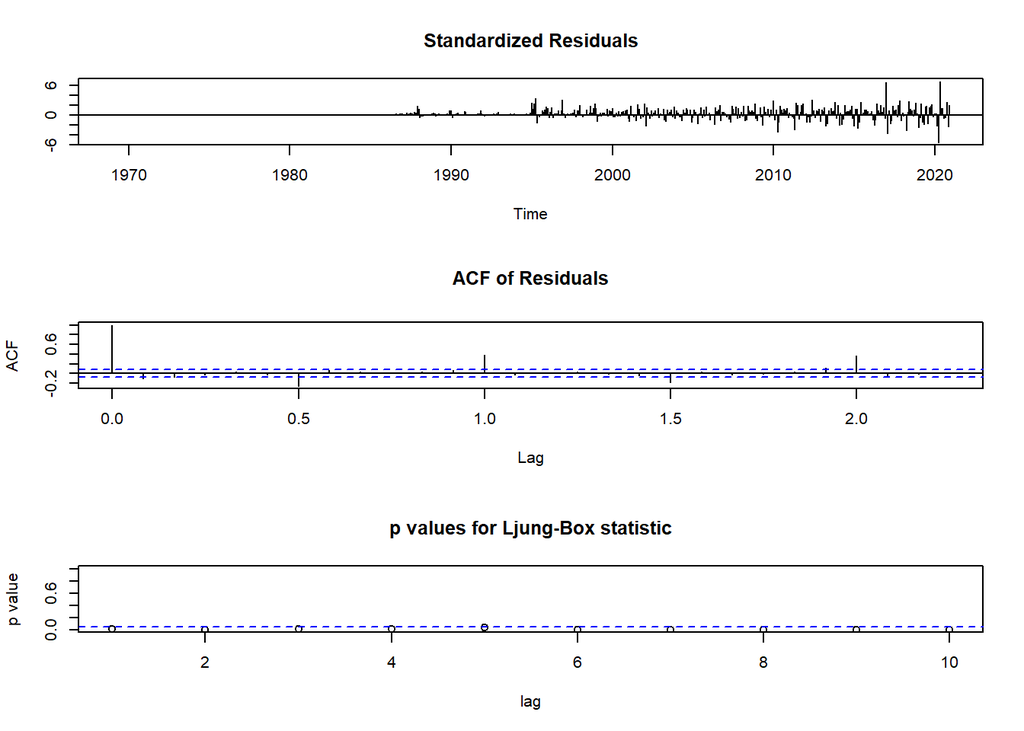

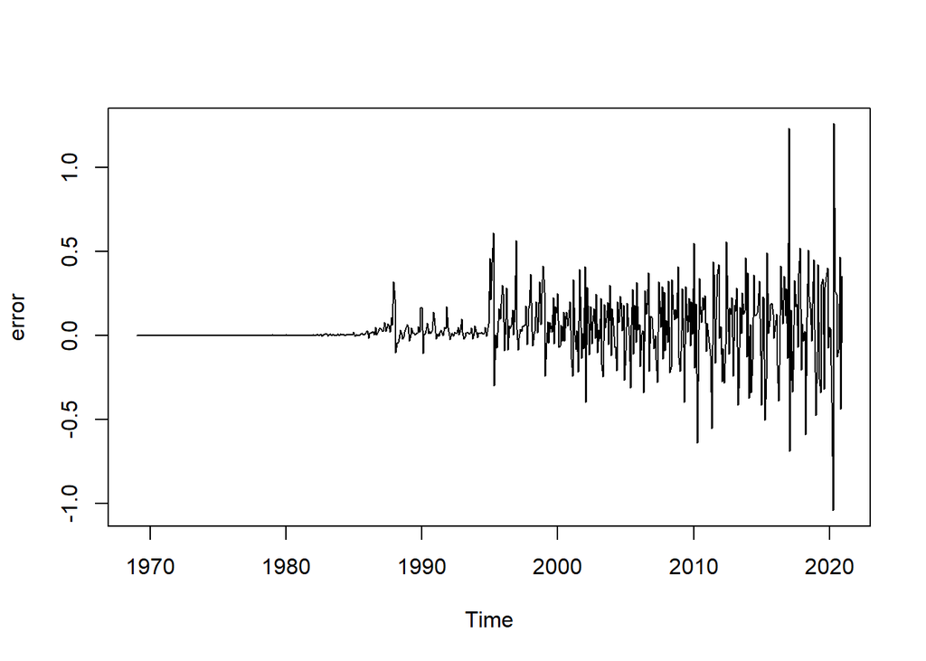

$$Q^{*}=T(T+2) \sum_{k=1}^{h}(T-k)^{-1} r_{k}^{2}$$

> Entonces, la hipótesis nula de estas pruebas es que la serie en cuestión **no está autocorrelacionada**. En otras palabras, la $H_0$ dice que **la serie es ruido blanco**. Si $\alpha$ es el nivel de significancia (el nivel máximo de error que estamos dispuestos a aceptar) y si el ¨*p-value* $< \alpha$, entonces **rechazamos $H_0$**, de lo contrario, no rechazamos la $H_0$.

# Valores ajustados *(fitted)* y residuales

Cada observación en una serie de tiempo puede ser pronosticada utilizando los datos históricos previos. A estos se les conoce como valores ajustados (o *fitted*), $\hat{y}_t$.

Los residuales en un modelo de series de tiempo es la información que el modelo no logró capturar. Esto es, es la diferencia entre los valores reales y los valores ajustados.

$$e_{t}=y_{t}-\hat{y}_{t}$$

Es muy importante analizar los residuos para determinar si nuestros modelos están bien ajustados. Si logramos detectar patrones en los residuales, puede ser indicio de que el modelo puede mejorarse.

# Diagnóstico de residuales

Un buen modelo de pronóstico va a producir residuales con las siguientes características:

1. **No están autocorrelacionados**. Si se detectan correlaciones entre residuos, todavía hay información útil que se debe modelar.
2. **La media de los residuos es cero**. Si la media es distinta de cero, entonces el pronóstico está sesgado.
3. Los residuos tienen una varianza constante.
4. Los residuos se distribuyen de manera normal.

```
##          Point Forecast    Lo 80    Hi 80    Lo 95    Hi 95
## Jan 2021       109.7206 109.4904 109.9508 109.3686 110.0727
## Feb 2021       110.0362 109.6146 110.4577 109.3915 110.6808
## Mar 2021       110.3506 109.7858 110.9155 109.4868 111.2145
## Apr 2021       110.6640 109.9727 111.3554 109.6067 111.7214
## May 2021       110.9764 110.1667 111.7860 109.7381 112.2146
## Jun 2021       111.2877 110.3643 112.2110 109.8755 112.6998
## Jul 2021       111.5979 110.5634 112.6324 110.0158 113.1800
## Aug 2021       111.9071 110.7629 113.0513 110.1572 113.6570
## Sep 2021       112.2153 110.9621 113.4685 110.2987 114.1319
## Oct 2021       112.5224 111.1603 113.8844 110.4393 114.6054
## Nov 2021       112.8284 111.3574 114.2995 110.5787 115.0782
## Dec 2021       113.1335 111.5530 114.7139 110.7164 115.5506
## Jan 2022       113.4375 111.7470 115.1279 110.8521 116.0228
## Feb 2022       113.7404 111.9392 115.5417 110.9857 116.4952
## Mar 2022       114.0424 112.1296 115.9552 111.1170 116.9678
## Apr 2022       114.3433 112.3180 116.3686 111.2459 117.4407
## May 2022       114.6432 112.5045 116.7820 111.3723 117.9142
## Jun 2022       114.9421 112.6889 117.1953 111.4961 118.3881
## Jul 2022       115.2400 112.8713 117.6087 111.6173 118.8627
## Aug 2022       115.5369 113.0516 118.0222 111.7360 119.3378
## Sep 2022       115.8328 113.2298 118.4357 111.8519 119.8136
## Oct 2022       116.1276 113.4060 118.8493 111.9653 120.2900
## Nov 2022       116.4215 113.5801 119.2629 112.0759 120.7671
## Dec 2022       116.7144 113.7521 119.6767 112.1839 121.2449
## Jan 2023       117.0063 113.9220 120.0906 112.2893 121.7233
## Feb 2023       117.2972 114.0899 120.5045 112.3920 122.2024
## Mar 2023       117.5871 114.2557 120.9186 112.4921 122.6822
## Apr 2023       117.8761 114.4194 121.3327 112.5896 123.1626
## May 2023       118.1641 114.5811 121.7470 112.6845 123.6436
## Jun 2023       118.4510 114.7408 122.1613 112.7767 124.1253
## Jul 2023       118.7371 114.8985 122.5757 112.8665 124.6077
## Aug 2023       119.0221 115.0542 122.9901 112.9537 125.0906
## Sep 2023       119.3062 115.2079 123.4046 113.0383 125.5741
## Oct 2023       119.5894 115.3596 123.8191 113.1205 126.0583
## Nov 2023       119.8715 115.5093 124.2337 113.2001 126.5429
## Dec 2023       120.1528 115.6572 124.6484 113.2773 127.0282
```

```
## Series: datos
## ARIMA(2,1,5)(0,1,2)[12]
##
## Coefficients:
##          ar1     ar2     ma1      ma2      ma3      ma4     ma5     sma1
##       0.1467  0.7557  0.3874  -0.6242  -0.3138  -0.0963  0.1027  -0.8251
## s.e.  0.0682  0.0648  0.0754   0.0562   0.0591   0.0427  0.0577   0.0528
##         sma2
##       0.0897
## s.e.  0.0490
##
## sigma^2 = 0.02095:  log likelihood = 312.85
## AIC=-605.71   AICc=-605.34   BIC=-561.56
```

```
##
##  Box-Ljung test
##
## data:  residuals(propuesta.auto)
## X-squared = 0.0074298, df = 1, p-value = 0.9313
```

## Selección de modelos ARIMA

Una manera de escoger entre dos modelos distintos de los mismos datos es a través de los criterios de información:

- Criterio de información de Akaike (AIC).
- Criterio de información de Akaike corregido por sesgo de muestras pequeñas ($AIC_c$).
- Criterio de información Bayesiano (BIC).

Se sugiere utilizar el $AIC_c$. Recordando, entre menor sea el valor de los criterios de información, mejor ajuste tendrá el modelo.

# Metodología Box-Jenkins

¿Cómo se escoge el orden del modelo (*p,d,q*)? Se pueden seguir los siguientes pasos para intentar encontrar el modelo ARIMA óptimo para una serie de tiempo no estacional. Es un proceso iterativo y, en cierto grado, de prueba y error:

1. Graficar los datos e identificar observaciones inusuales.
2. Si es necesario, transformar los datos para estabilizar la varianza.
   - Comúnmente se utilizará una transformación Box-Cox.
3. Si la serie es no estacionaria, diferenciarla hasta convertirla en estacionaria.
   - Aquí entran las pruebas de raíz unitaria como la KPSS.
4. Revisar las gráficas de las funciones ACF y PACF y decidir los órdenes *p,q*.
5. Ajuste el modelo escogido y revise la $AIC_c$ correspondiente para comparar vs. otros modelos.
6. Lleve a cabo el diagnóstico de residuos.
   - Grafique la ACF y los tests de portmanteau. Si los residuos no parecen ruido blanco, intente refinando el modelo.
7. Una vez que se cuenta con residuos similares a ruido blanco, realizar los pronósticos.

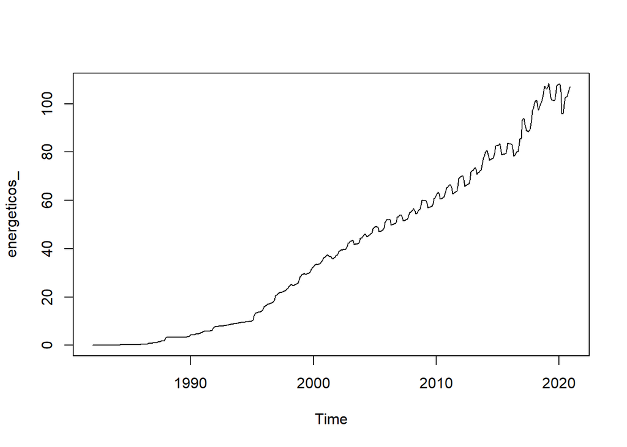

```
##      Min.   1st Qu.    Median      Mean   3rd Qu.      Max.
##   0.04516   6.01064  36.86411  39.44831  64.16278 108.35334
```

```
## [1] 33.30472
```

```
## [1] 1109.204
```

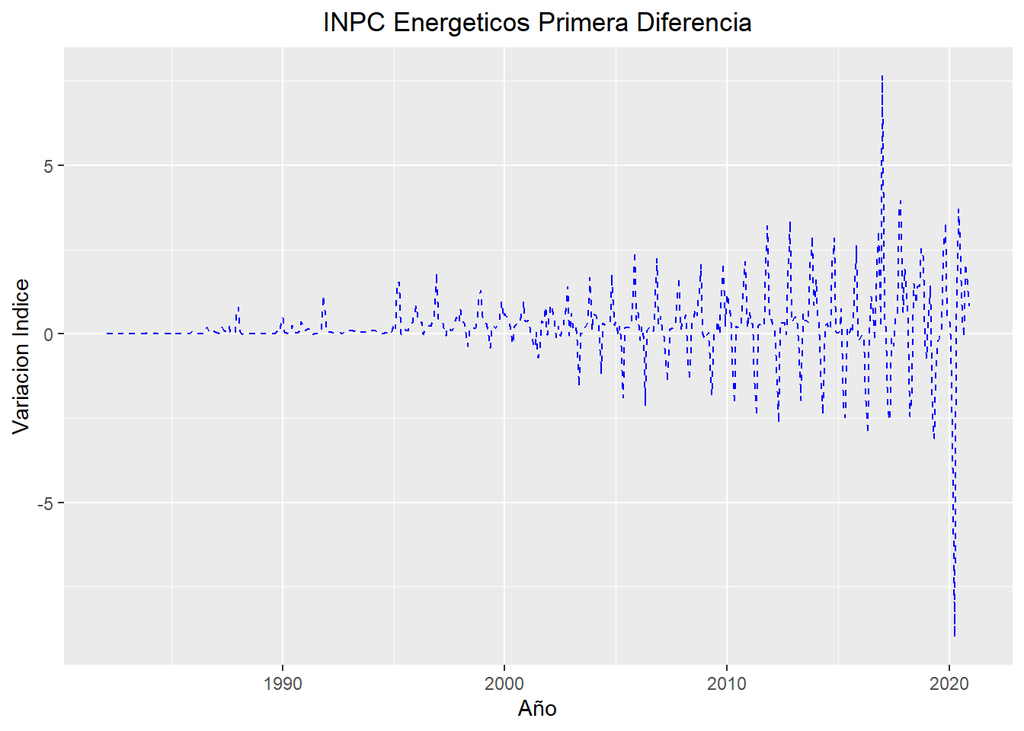

```
## Augmented Dickey-Fuller Test
## alternative: stationary
##
## Type 1: no drift no trend
##      lag   ADF p.value
## [1,]   0 -13.9    0.01
## [2,]   1 -13.2    0.01
## [3,]   2 -11.1    0.01
## [4,]   3 -10.2    0.01
## [5,]   4 -11.7    0.01
## [6,]   5 -16.4    0.01
## Type 2: with drift no trend
##      lag   ADF p.value
## [1,]   0 -14.3    0.01
## [2,]   1 -13.8    0.01
## [3,]   2 -11.8    0.01
## [4,]   3 -10.9    0.01
## [5,]   4 -12.9    0.01
## [6,]   5 -19.4    0.01
## Type 3: with drift and trend
##      lag   ADF p.value
## [1,]   0 -14.4    0.01
## [2,]   1 -13.9    0.01
## [3,]   2 -11.9    0.01
## [4,]   3 -11.1    0.01
## [5,]   4 -13.2    0.01
## [6,]   5 -20.1    0.01
## ----
## Note: in fact, p.value = 0.01 means p.value <= 0.01
```

```
## Augmented Dickey-Fuller Test
## alternative: stationary
##
## Type 1: no drift no trend
##      lag   ADF p.value
## [1,]   0 1.611   0.974
## [2,]   1 0.979   0.911
## [3,]   2 0.947   0.907
## [4,]   3 0.810   0.877
## [5,]   4 0.489   0.785
## [6,]   5 0.523   0.794
## Type 2: with drift no trend
##      lag   ADF p.value
## [1,]   0 -8.73    0.01
## [2,]   1 -6.74    0.01
## [3,]   2 -7.39    0.01
## [4,]   3 -7.43    0.01
## [5,]   4 -6.32    0.01
## [6,]   5 -7.09    0.01
## Type 3: with drift and trend
##      lag   ADF p.value
## [1,]   0 -4.42  0.0100
## [2,]   1 -3.82  0.0174
## [3,]   2 -4.27  0.0100
## [4,]   3 -4.50  0.0100
## [5,]   4 -4.23  0.0100
## [6,]   5 -4.76  0.0100
## ----
## Note: in fact, p.value = 0.01 means p.value <= 0.01
```

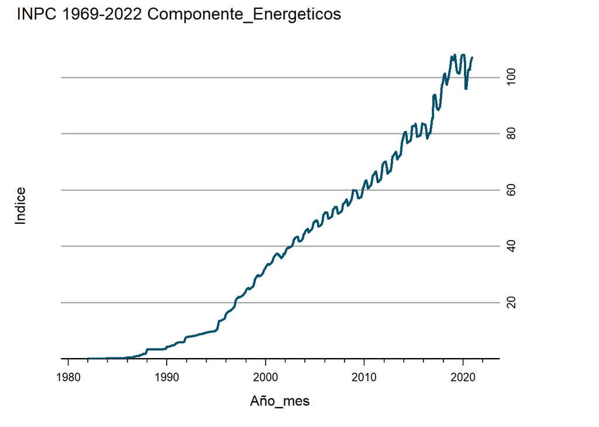

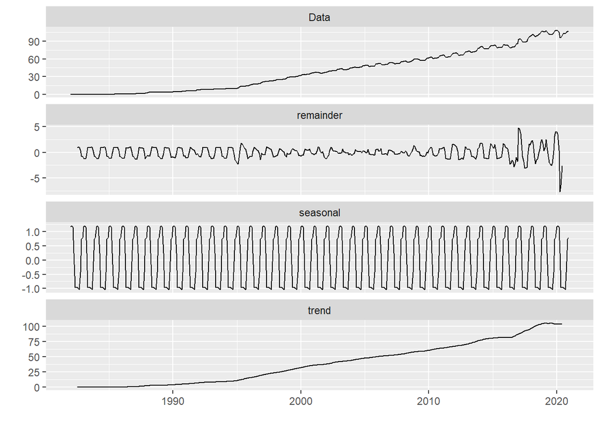

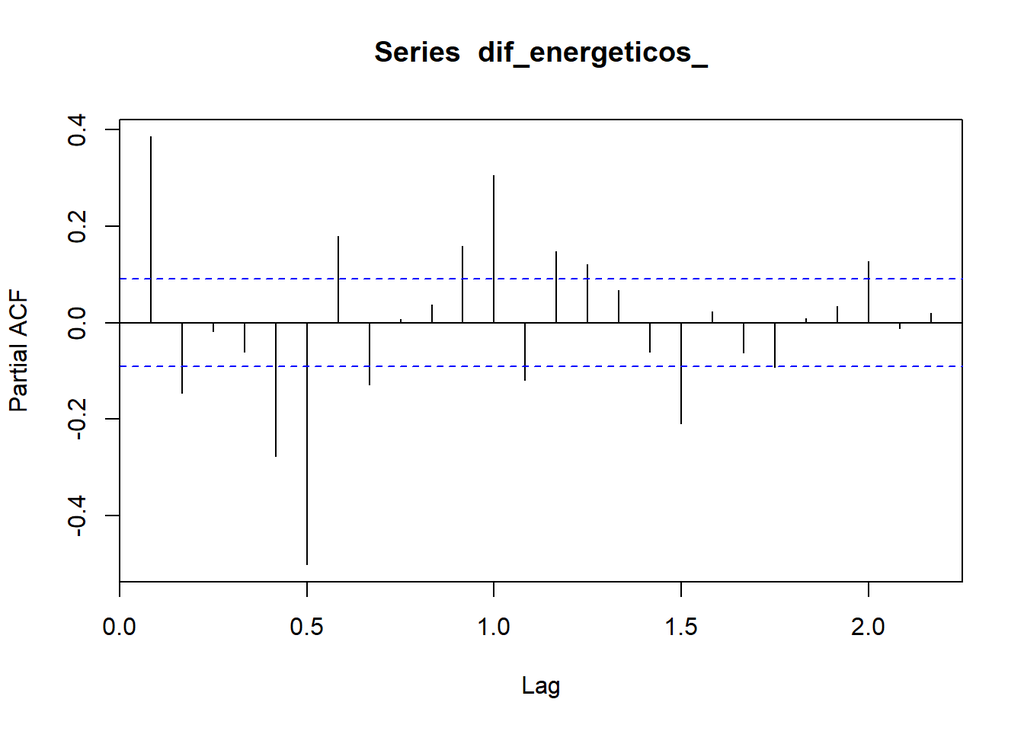

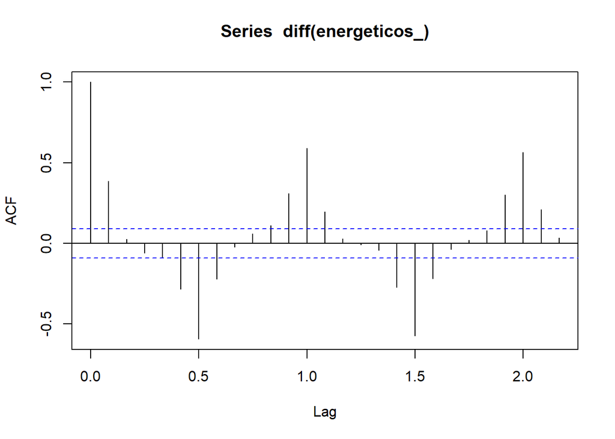

```
## Series: energeticos_
## ARIMA(0,1,1)(0,1,2)[12]
##
## Coefficients:
##          ma1     sma1    sma2
##       0.3194  -0.7284  0.0774
## s.e.  0.0467   0.0674  0.0627
##
## sigma^2 = 0.4437:  log likelihood = -463.01
## AIC=934.03   AICc=934.12   BIC=950.51
```

```
##
##  Box-Ljung test
##
## data:  residuals(automodelo)
## X-squared = 0.036944, df = 1, p-value = 0.8476
```

```
##
## Call:
## arima(x = energeticos_, order = c(4, 1, 5), method = "ML")
##
## Coefficients:
##           ar1     ar2     ar3      ar4     ma1      ma2      ma3     ma4
##       -0.0125  1.0039  -9e-04  -0.9808  0.4275  -1.0906  -0.5487  0.9415
## s.e.   0.0091  0.0100   9e-03   0.0087  0.0403   0.0199   0.0481  0.0192
##          ma5
##       0.4999
## s.e.  0.0400
##
## sigma^2 estimated as 0.5755:  log likelihood = -539.38,  aic = 1098.77
```

```
##
##  Box-Ljung test
##
## data:  residuals(modelo415)
## X-squared = 3.9331, df = 1, p-value = 0.04734
```

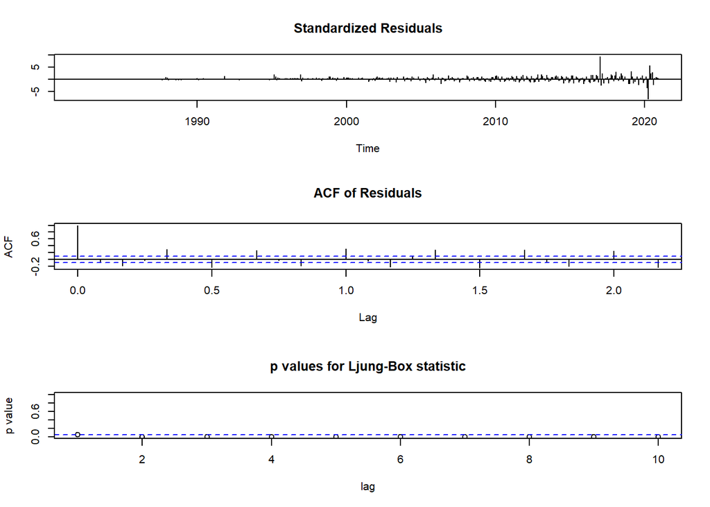

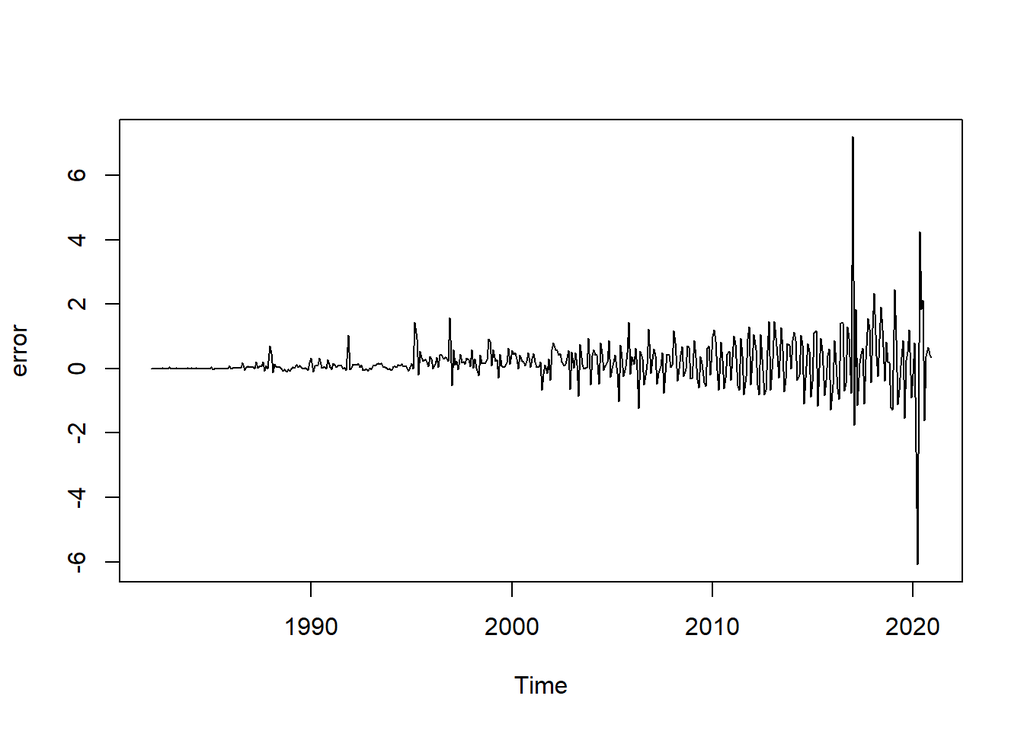

```
##          Point Forecast     Lo 80    Hi 80     Lo 95    Hi 95
## Jan 2021       107.4077 106.43343 108.3820 105.91768 108.8978
## Feb 2021       106.3470 104.65593 108.0382 103.76071 108.9334
## Mar 2021       105.8776 103.74660 108.0086 102.61852 109.1367
## Apr 2021       104.5770 102.14627 107.0077 100.85951 108.2945
## May 2021       103.9968 101.35271 106.6410  99.95298 108.0407
## Jun 2021       103.7391 100.91237 106.5659  99.41599 108.0623
## Jul 2021       103.6216 100.63787 106.6053  99.05840 108.1847
## Aug 2021       104.6404 101.48095 107.7999  99.80844 109.4724
## Sep 2021       105.0789 101.72697 108.4308  99.95257 110.2052
## Oct 2021       106.3491 102.77402 109.9242 100.88148 111.8168
## Nov 2021       106.8878 103.06054 110.7150 101.03451 112.7411
## Dec 2021       107.1566 103.07911 111.2341 100.92061 113.3926
## Jan 2022       107.2628 102.93503 111.5906 100.64404 113.8815
## Feb 2022       106.2851 101.74605 110.8241  99.34325 113.2269
## Mar 2022       105.8753 101.15571 110.5949  98.65731 113.0933
## Apr 2022       104.6351  99.77207 109.4981  97.19774 112.0724
## May 2022       104.1360  99.15984 109.1122  96.52561 111.7464
## Jun 2022       103.8565  98.77770 108.9353  96.08915 111.6238
## Jul 2022       103.7620  98.59088 108.9331  95.85346 111.6706
## Aug 2022       104.6994  99.42229 109.9765  96.62877 112.7700
## Sep 2022       105.0825  99.68728 110.4778  96.83120 113.3339
## Oct 2022       106.2930 100.75699 111.8291  97.82638 114.7597
## Nov 2022       106.7544 101.05555 112.4532  98.03877 115.4700
## Dec 2022       107.0441 101.17803 112.9103  98.07270 116.0156
## Jan 2023       107.1267 101.08810 113.1653  97.89145 116.3620
## Feb 2023       106.2290 100.03998 112.4179  96.76373 115.6942
## Mar 2023       105.8704  99.54845 112.1923  96.20184 115.5389
## Apr 2023       104.6893  98.25910 111.1195  94.85517 114.5234
## May 2023       104.2639  97.74553 110.7823  94.29492 114.2329
## Jun 2023       103.9643  97.36498 110.5637  93.87150 114.0571
## Jul 2023       103.8938  97.22071 110.5669  93.68818 114.0995
## Aug 2023       104.7527  97.99526 111.5102  94.41808 115.0874
## Sep 2023       105.0887  98.23799 111.9394  94.61145 115.5659
## Oct 2023       106.2406  99.27895 113.2023  95.59366 116.8876
## Nov 2023       106.6319  99.54251 113.7212  95.78963 117.4741
## Dec 2023       106.9407  99.71895 114.1625  95.89596 117.9855
```

```
##
##  Phillips-Perron Unit Root Test
##
## data:  y
## Dickey-Fuller = -1.0738, Truncation lag parameter = 5, p-value = 0.9266
```

```
##
##  Phillips-Perron Unit Root Test
##
## data:  energeticos_
## Dickey-Fuller = -2.5416, Truncation lag parameter = 5, p-value = 0.3489
```

```r
dif_y <- diff(y)
# Las series con la primera diferencia son estacionarias
PP.test(dif_y)
```

```
##
##  Phillips-Perron Unit Root Test
##
## data:  dif_y
## Dickey-Fuller = -7.9537, Truncation lag parameter = 5, p-value = 0.01
```

```r
PP.test(dif_energeticos_)
```

```
##
##  Phillips-Perron Unit Root Test
##
## data:  dif_energeticos_
## Dickey-Fuller = -14.096, Truncation lag parameter = 5, p-value = 0.01
```

```r
y <- dif_y
x <- dif_energeticos_

bfx <- as.matrix(cbind(y,x))
po.test(bfx)
```

```
##
##  Phillips-Ouliaris Cointegration Test
##
## data:  bfx
## Phillips-Ouliaris demeaned = -74.148, Truncation lag parameter = 4,
## p-value = 0.01
```

```r
#En este caso p_value < 0.05 por lo tanto rechazamos la hipótesis
# nula, existe evidencia para sostener que las series son cointegradas,
#es decir que hay una tendencia a largo plazo.
```

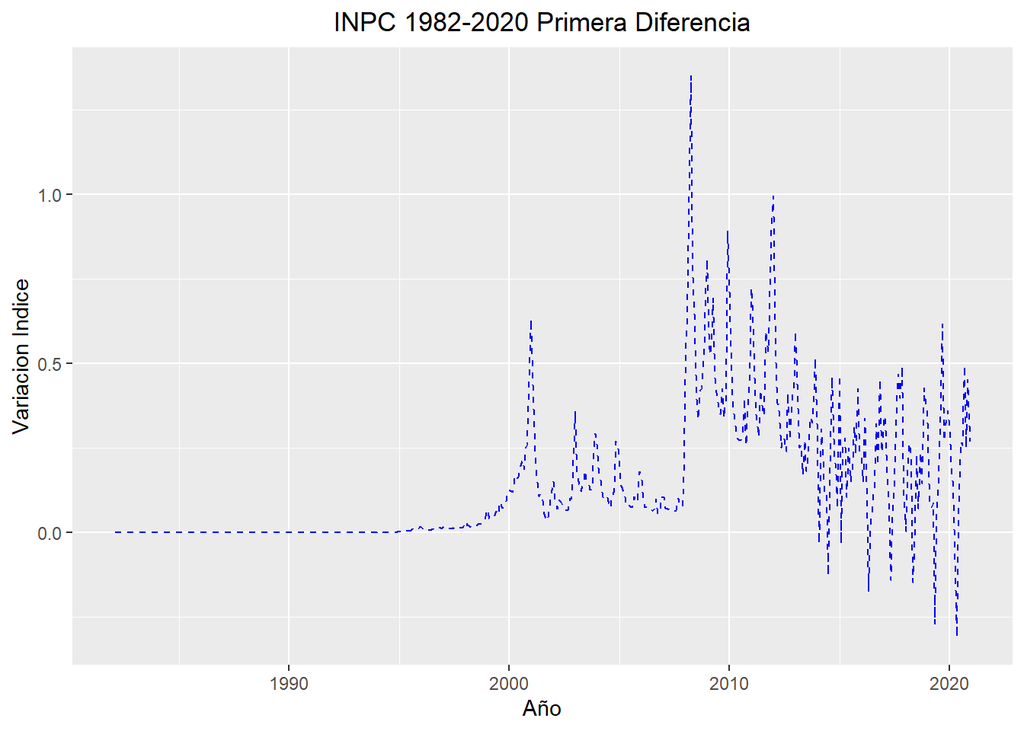

```r
ggplot2::autoplot(dif_y, ts.colour = "blue",
                  ts.linetype = "dashed") +
  ggtitle("INPC 1982-2020 Primera Diferencia") +
  xlab("Año") + ylab("Variacion Indice") +
  theme(plot.title = element_text(hjust = 0.5))
```

En la literatura podemos encontrar muchos nombres para las variables $y$ ^ $x$. P. ej.

| $y$ (var. de pronóstico) | $x$ (vars. predictoras) |
| --- | --- |
| Var. dependiente | Vars. independientes |
| Explicada | Explicativas |
| Regresada | Regresoras |
| Respuesta | Estímulo |
| Resultado | Covariante |
| Controlada | De control |

# El modelo lineal

El caso más sencillo sería un **modelo de regresión lineal simple**, de la forma:

$$y_t = \beta_0 + \beta_1 x_t + \varepsilon_t$$

donde

- $\beta_0$ es conocido como el *intercepto* y representa el **valor predicho cuando $x = 0$.**
- $\beta_1$ es la *pendiente* de la recta. Nos indica el **cambio promedio en $y$, ante un cambio en una unidad de $x$**.
- El término de error, $\varepsilon_t$ se asume aleatorio y decimos que captura los cambios debido a todas las otras variables que pudieran llegar a afectar a $y_t$, que no están explícitamente especificadas en el modelo.

La recta resultante está dada entonces por $\beta_0 + \beta_1 x_t$, y la diferencia que existe en los puntos reales y ésta es $\varepsilon_t$.

[*[(Hyndman, 2019)](https://otexts.com/fpp3/)*]

Recordando, un modelo de regresión tiene la forma general

$$y_{t}=\beta_{0}+\beta_{1} x_{1,
t}+\cdots+\beta_{k} x_{k, t}+\varepsilon_{t}$$

donde $y_t$ es la variable que queremos pronosticar, $x_{k, t}$ son las variables independientes que utilizábamos para explicar a $y_t$ y $\varepsilon_{t}$ es el término de error no correlacionado (ruido blanco).

```r
mmC1 <- lm(formula= y ~ x)
summary(mmC1)
```

```
##
## Call:
## lm(formula = y ~ x)
##
## Residuals:
##      Min       1Q   Median       3Q      Max
## -0.44275 -0.13097 -0.07983  0.08133  1.25202
##
## Coefficients:
##             Estimate Std. Error t value Pr(>|t|)
## (Intercept) 0.130797   0.009281  14.093  < 2e-16 ***
## x           0.036946   0.008650   4.271 2.36e-05 ***
## ---
## Signif. codes:  0 '***' 0.001 '**' 0.01 '*' 0.05 '.' 0.1 ' ' 1
##
## Residual standard error: 0.1959 on 465 degrees of freedom
## Multiple R-squared:  0.03775,    Adjusted R-squared:  0.03568
## F-statistic: 18.24 on 1 and 465 DF,  p-value: 2.36e-05
```

```r
residuales <- mmC1$residuals
summary(residuales)
```

```
##     Min.  1st Qu.   Median     Mean  3rd Qu.     Max.
## -0.44275 -0.13097 -0.07983  0.00000  0.08133  1.25202
```

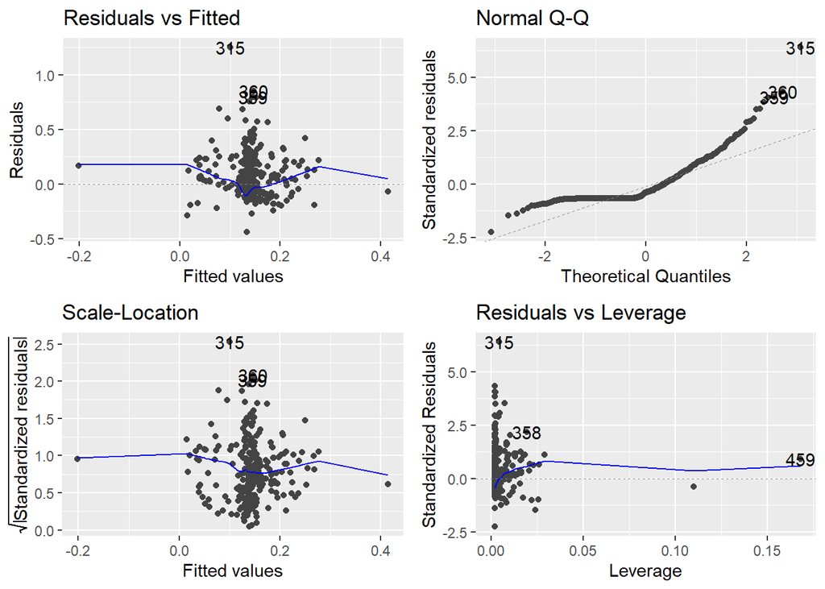

```r
autoplot(mmC1)
```

```r
adf.test(residuales)
```

```
## Augmented Dickey-Fuller Test
## alternative: stationary
##
## Type 1: no drift no trend
##      lag   ADF p.value
## [1,]   0 -6.98    0.01
## [2,]   1 -6.13    0.01
## [3,]   2 -4.91    0.01
## [4,]   3 -4.67    0.01
## [5,]   4 -4.06    0.01
## [6,]   5 -4.21    0.01
## Type 2: with drift no trend
##      lag   ADF p.value
## [1,]   0 -6.97    0.01
## [2,]   1 -6.12    0.01
## [3,]   2 -4.91    0.01
## [4,]   3 -4.67    0.01
## [5,]   4 -4.05    0.01
## [6,]   5 -4.20    0.01
## Type 3: with drift and trend
##      lag   ADF p.value
## [1,]   0 -8.58    0.01
## [2,]   1 -7.71    0.01
## [3,]   2 -6.26    0.01
## [4,]   3 -6.05    0.01
## [5,]   4 -5.32    0.01
## [6,]   5 -5.59    0.01
## ----
## Note: in fact, p.value = 0.01 means p.value <= 0.01
```

```r
library(urca)
yy<-ur.df(residuales, type="trend",selectlags="AIC")

summary(yy)
```

```
##
## ###############################################
## # Augmented Dickey-Fuller Test Unit Root Test #
## ###############################################
##
## Test regression trend
##
##
## Call:
## lm(formula = z.diff ~ z.lag.1 + 1 + tt + z.diff.lag)
##
## Residuals:
##      Min       1Q   Median       3Q      Max
## -0.61054 -0.02811 -0.00669  0.01318  0.66140
##
## Coefficients:
##               Estimate Std. Error t value Pr(>|t|)
## (Intercept) -4.992e-02  1.236e-02  -4.040 6.26e-05 ***
## z.lag.1     -2.659e-01  3.450e-02  -7.706 8.01e-14 ***
## tt           2.157e-04  4.785e-05   4.508 8.32e-06 ***
## z.diff.lag  -3.185e-02  4.664e-02  -0.683    0.495
## ---
## Signif. codes:  0 '***' 0.001 '**' 0.01 '*' 0.05 '.' 0.1 ' ' 1
##
## Residual standard error: 0.1123 on 461 degrees of freedom
## Multiple R-squared:  0.1381, Adjusted R-squared:  0.1325
## F-statistic: 24.62 on 3 and 461 DF,  p-value: 8.56e-15
##
##
## Value of test-statistic is: -7.7064 19.8017 29.6947
##
## Critical values for test statistics:
##       1pct  5pct 10pct
## tau3 -3.98 -3.42 -3.13
## phi2  6.15  4.71  4.05
## phi3  8.34  6.30  5.36
```

# Pronóstico

Para llevar a cabo pronósticos de modelos de regresión con errores ARIMA, se necesita realizar el pronóstico de

- la parte de la regresión
- la parte de los errores ARIMA

y combinar los resultados.

Una característica con estos modelos, es que necesitamos pronósticos de las variables independientes $x_t$ o predictoras para poder pronosticar nuestra variable de interés, $y_t$. Cuando las predictoras son conocidas en el futuro, como variables de calendario (tiempo, día de la semana, mes, etc.), no hay mayor problema. Pero, cuando son desconocidas, tenemos que o modelarlas por separado, o asumir valores futuros para cada una.

**NOTA:** Los intervalos de predicción de modelos de regresión (regresión lineal múltiple o modelos con errores ARIMA), no toman en cuenta la incertidumbre de las predictoras. Así, el modelo *asume* que esas predicciones son correctas. En otras palabras, los intervalos de predicción son condicionales al cumplimiento de los valores de las predictoras.

Recordando, un modelo de regresión tiene la forma general

$$y_{t}=\beta_{0}+\beta_{1} x_{1,
t}+\cdots+\beta_{k} x_{k, t}+\varepsilon_{t}$$

donde $y_t$ es la variable que queremos pronosticar, $x_{k, t}$ son las variables independientes que utilizábamos para explicar a $y_t$ y $\varepsilon_{t}$ es el término de error no correlacionado (ruido blanco).

El término de regresión fue acuñado por primera vez por Francis Galton en 1886. Él estaba estudiando la relación que existe entre la estatura de los hijos y la estatura de los padres.

Lo que encontró fue lo siguiente, en resumen:

- Los padres más altos, tendían a tener hijos más altos, mientras que los padres bajos tendían a tener hijos bajos.
- En promedio, los hijos de padres altos no logran ser más altos que ellos. Similarmente, los hijos de padres bajos, en promedio son más altos que sus papás.
- Así, Galton decía que había una tendencia a **regresar** a la estatura promedio.

Entonces, *el análisis de regresión en tiempos modernos trata sobre la relación de la dependencia entre una variable $y$, respecto de una o más variables exógenas (regresoras $x$) para predecir el valor promedio de la variable dependiente.*